# Hypothesis Testing of Drink Preference

# Reading Survey Data and libraries

```r
data <- read.csv('coffeetea.csv')
library(dplyr)
```

# Preparing Raw and Unstructered Data to Useful data

```r
finaldata = data[!duplicated(data$Email.Address), ]
```

# Exploratory Data Analysis

```r
summary(finaldata[,2:7])
```

```
##  Do.you.prefer.tea.or.coffee. How.many.times.do.you.drink.it.on.daily.basis.
##  Coffee:31                    1        :31
##  None  : 3                    2        :20
##  Tea   :32                    3 or more: 5
##                               Never    :10
##
##
##
##     Gender     Nationality    Age                     Email.Address
##  Female:32   American: 2   >30  : 1   301194sach@gmail.com   : 1
##  Male  :34   Chinese :17   18-20: 3   8888@husky.nau.edu     : 1
##              Indian  :42   21-30:62   a@b.com                : 1
##              Taiwan  : 4              abc70177@hotmail.com   : 1
##              Thai    : 1              amalsharma24@gmail.com : 1
##                                       angikasingh54@gmail.com: 1
##                                       (Other)                :60
```

- We have collected 6 attributes of data namely
- 1. Do you prefer Coffee?
- 2. Number of drinks/day
- 3. Gender
- 4. Nationality
- 5. Age
- 6. Email Address

##### Our main attribute (on which we are going to perform our analysis) is Drink Preference (1st attribute)

# Drink Preference Analysis

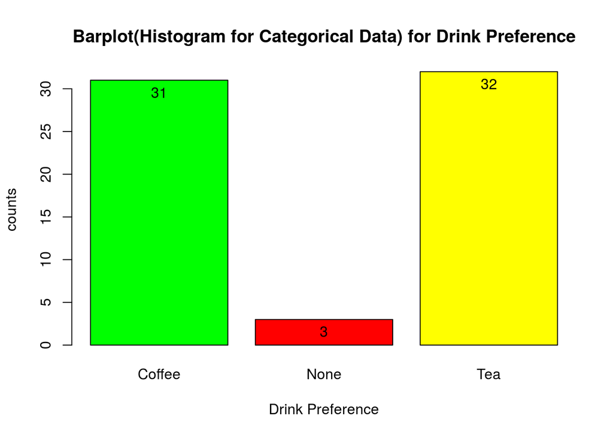

```r
counts = table(finaldata$Do.you.prefer.tea.or.coffee.)

x = barplot(counts, main="Barplot(Histogram for Categorical Data) for Drink Preference",
  xlab="Drink Preference", ylab='counts', col = c("green","red", "yellow"), beside = TRUE)

text(x, counts, labels = counts ,cex=1, pos = 1)
```

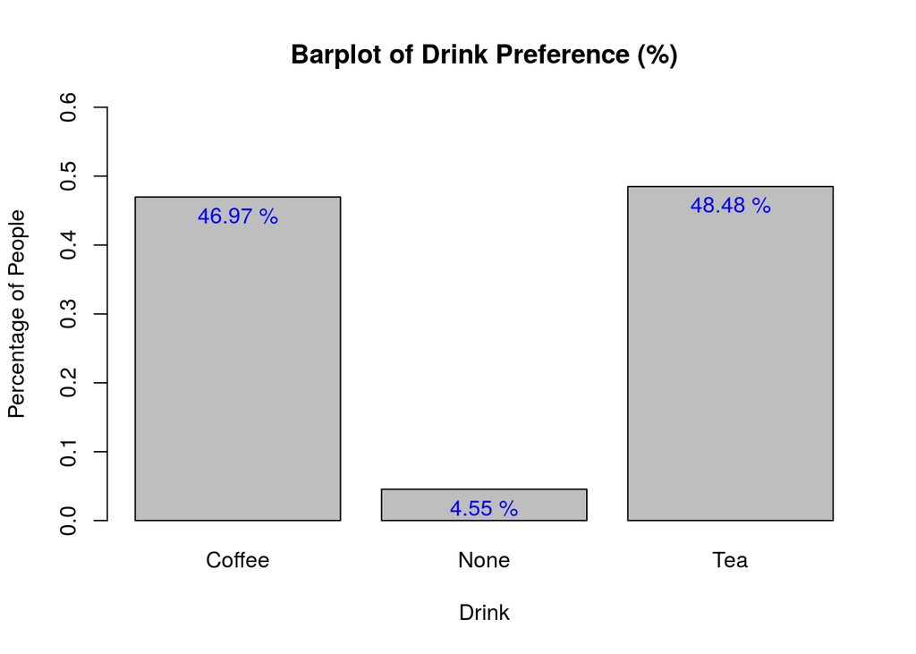

```r
x = barplot(prop.table(table(finaldata$Do.you.prefer.tea.or.coffee.)), main = 'Barplot of Drink Preference (%)', xlab = 'Drink', ylab = 'Percentage of People', ylim = c(0,0.6))

text(x, prop.table(table(finaldata$Do.you.prefer.tea.or.coffee.)), labels = paste(round(prop.table(table(finaldata$Do.you.prefer.tea.or.coffee.)), digits = 4)*100, "%") ,cex=1, col = "blue", pos = 1)
```

##### Barplots are the histograms of Categorical Variables

##### We see that 46.97% of of our sample prefers Coffee, while 48.48% perfer Tea and 4.55% doesn’t prefer any of the drink

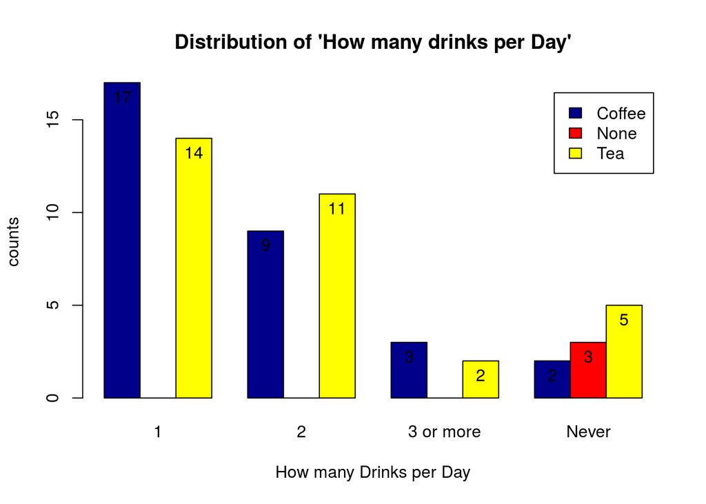

```r
counts = table(finaldata$Do.you.prefer.tea.or.coffee., finaldata$How.many.times.do.you.drink.it.on.daily.basis.)

x = barplot(counts, main="Distribution of 'How many drinks per Day'",
  xlab="How many Drinks per Day", ylab='counts', col = c("darkblue","red","yellow"),legend = rownames(counts), beside=TRUE)

text(x, counts, labels = counts ,cex=1, pos = 1)
```

##### The distribution of the drinks per day with respect to Drink Preference is shown in the graph.

- More Coffee drinkers have 1 drink per day than tea drinkers
- While more Tea drinkers have 2 drinks per day than coffee drinkers
- 7 people have a preference over Coffee or Tea but don’t drink it on a daily basis
- 3 people have no preference of tea or coffe and doesn’t drink them on a daily basis

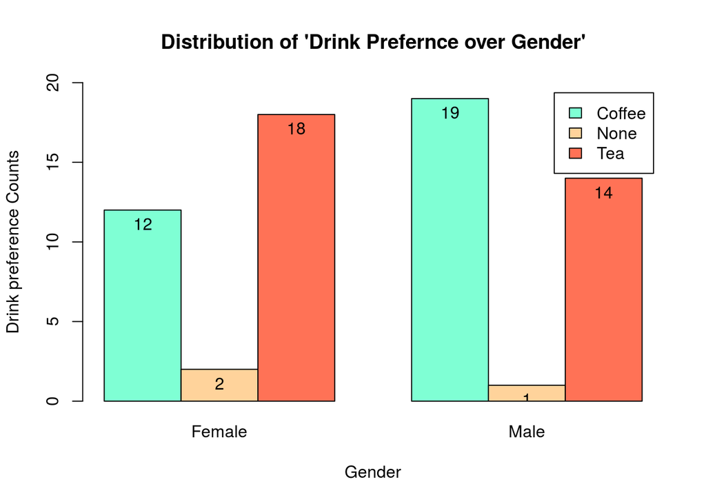

```r
counts = table(finaldata$Do.you.prefer.tea.or.coffee., finaldata$Gender)

x = barplot(counts, main="Distribution of 'Drink Prefernce over Gender'",
  xlab="Gender", ylab='Drink preference Counts', col = c('aquamarine', 'burlywood1', 'coral1'), legend = rownames(counts), beside=TRUE, ylim = c(0,20))

text(x, counts, labels = counts ,cex=1, pos = 1)
```

##### The distribution drink preference with respect to the gender is shown in the above graph.

- It’s an interesting fact that more Males prefer Coffee than Females.
- While more Females prefer Tea than Males

#### Altering the Drink Preference column to a bi-valued column. - According to our statistical analysis, the column should have 2 values - ‘Coffee’, ‘Not Coffee’

```r
finaldata$Do.you.prefer.tea.or.coffee. = as.character(finaldata$Do.you.prefer.tea.or.coffee.)

finaldata$Do.you.prefer.tea.or.coffee.[finaldata$Do.you.prefer.tea.or.coffee. != 'Coffee'] = 'Not Coffee'
```

##### Now let’s look at the distribution of how the drink preference looks like

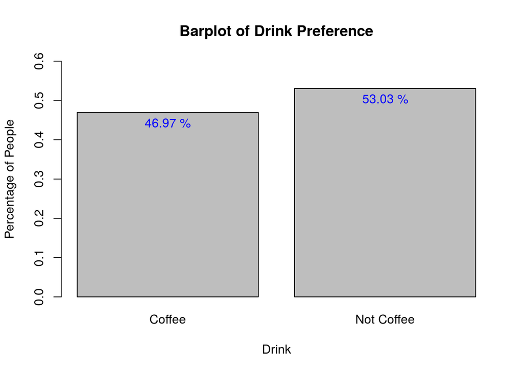

```r
x = barplot(prop.table(table(finaldata$Do.you.prefer.tea.or.coffee.)), main = 'Barplot of Drink Preference', xlab = 'Drink', ylab = 'Percentage of People', ylim = c(0,0.6))

text(x, prop.table(table(finaldata$Do.you.prefer.tea.or.coffee.)), labels = paste(round(prop.table(table(finaldata$Do.you.prefer.tea.or.coffee.)), digits = 4)*100, "%") ,cex=1, col = "blue", pos = 1)
```

##### We can simply say that 46.97% prefer Coffee while 53.03% doesn’t prefer Coffee

# Statistical Analysis

### Null Hypothesis: The proportion of people who prefer coffee will be equal to the proportion of people who don’t prefer Coffee

### Alternate Hypothesis: There proportion of people who prefer cofffe will not be equal to the proportion of people who don’t prefer coffee

- Sample Size n

```r
n = length(finaldata$Do.you.prefer.tea.or.coffee.)
```

- Sample size n = 66

Here Null Hypothesis says that P = P0. So we have P = P0 = 0.5

### Calculating P_hat

```r
p0 = 0.5
p_hat = length(subset(finaldata$Do.you.prefer.tea.or.coffee., finaldata$Do.you.prefer.tea.or.coffee. == 'Coffee'))/length(finaldata$Do.you.prefer.tea.or.coffee.)

print(p_hat)
```

```
## [1] 0.469697
```

#### Confidence Intervals

- The Confidence Intervals for the above are p_hat - E and p_hat + E. Where E is the Error.

CI: (p_hat-E, p_hat+E)

where E = z * sqrt(p_hat*q_hat / n)

and We have q_hat = 1 - p_hat

#### Our Confidence level is 95%

Hence alpha = 0.05 and alpha/2 = 0.025 Hence we have to calculate z-value for 1-0.025 = 0.975

```r
E = qnorm(0.975)*sqrt(p_hat*(1-p_hat)/n)
print(E)
```

```
## [1] 0.1204057
```

##### Hence the Error for the confodence interval is 0.12

```r
Lower_CI = p_hat - E
Upper_CI = p_hat + E

print(Lower_CI)
```

```
## [1] 0.3492913
```

```r
print(Upper_CI)
```

```
## [1] 0.5901027
```

##### Lower Confidence Interval = 0.34929

##### Upper Confidence Interval = 0.59010

#### We can say that, with 95% confidence, the population proportion of people who prefer coffee will definetly be in the range (0.349, 0.590)

### Calculating Test Statistic

```r
z = (p_hat - p0)/sqrt(p0*(1-p0)/n)
print(z)
```

```
## [1] -0.492366
```

### Calculating p-value

```r
p_value = 2*pnorm(z)
print(p_value)
```

```
## [1] 0.6224607
```